# QUAD Center Cumulative Grant Period Report

Sophia Rabbanian

October 19th 2022 - April 29th 2026

The following report summarizes tutoring records for the entirety of the data collection period of the QUAD Center (October 19th 2022 - April 29th 2026). Please note that the data collection strategies and fields have shifted greatly over the years of the collection, so missing data is apparent and may lead to some inconsistencies.

# 0. Missing Data Overview

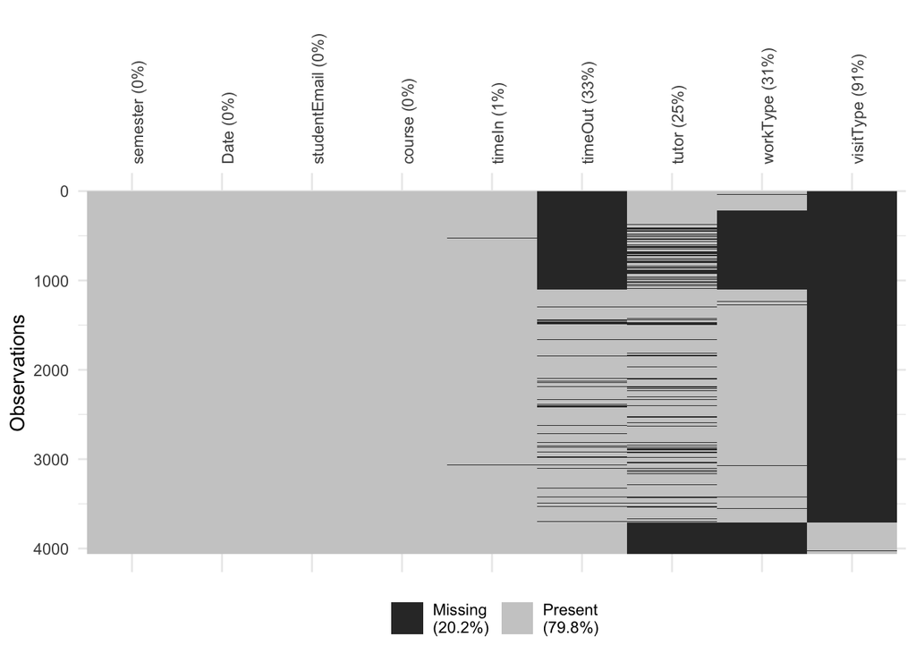

#### Notes:

- Over the 4 years, 80% of our data is present, with the first 4 columns being 100% complete. The percentage next to each column name represents the percentage of missing data in that column.
- The time out column was not collected until Fall 2024. This was collected to measure the duration of tutoring sessions.
- Any scattered areas of black (missing data) is caused by tutors or students forgetting to sign in or out when they entered or exited the QUAD Center. In more recent years, the tutors have been more consistent in reminding students to sign in and out, leading to less missing values.
- The later columns, specifically workType and visitType, have not been collected for every semester, which is why we see such big gaps in the data.
- Work type holds information on the type of assignment the tutoring session addressed (project, homework, etc.), while visit type represents what people were doing in the QUAD Center (studying, seeking tutoring, or just hanging out). Visit type was logged starting in 2026 because students often come to the QUAD Center to work on assignments, even if not explicitly seeking tutoring.
- The tutor column contains the name of the tutor who facilitated each session. It was not often used in reports and analyses, so it is no longer collected.

# 1. Overall Statistics

## 1.1 Class Counts

Class and Department Summary

| Total Tutor Sessions Count | Class Count | Department Count |
| --- | --- | --- |
| 4061 | 70 | 16 |

#### Notes:

- The classes count represents all of the unique courses that were tutored in the QUAD Center.
- The department count is the number of unique departments or class types that were tutored. While a majority of the sessions are for CS, DATA or MATH, the wide range of class types can be explained by some classes using coding software that the QUAD supports, or theory based classes that a specific tutor could serve.

## 1.2 Time Analysis

Session Time Summary (minutes)

| Minimum Time | Median Time | Average Time | Maximum Time |
| --- | --- | --- | --- |
| 1 | 60 | 69 | 283 |

#### Notes:

- This table shows the duration of tutoring sessions.
- The minimum time spent in the QUAD Center being 1 minute could be explained by either an extra credit assignment that required students to visit the QUAD and take a picture with a tutor, or by someone popping in to ask a quick question.
- The maximum duration of 283 minutes (4 hours, 43 minutes) was a tutoring session for CS-151, which frequently had long tutoring sessions, as it is a challenging and popular intro CS class.

## 1.3 Department Analysis

### 1.3.1 Tutor Demand by Department Summary

Tutored Demand by Department

| Department | Count | Percent of Demand |
| --- | --- | --- |
| CS | 2071 | 51.0% |
| DATA | 1494 | 36.8% |
| MATH | 310 | 7.6% |
| STAT | 58 | 1.4% |
| PSYC | 53 | 1.3% |
| UNKNOWN | 37 | 0.9% |
| PHEAL | 16 | 0.4% |
| BIO | 5 | 0.1% |
| IDS | 5 | 0.1% |
| GSM | 3 | 0.1% |
| ECON | 2 | 0.0% |
| ENVS | 2 | 0.0% |
| Independent | 2 | 0.0% |
| CHEM | 1 | 0.0% |
| EXHS | 1 | 0.0% |
| SOC | 1 | 0.0% |

### 1.3.2 Department Analysis Visualized

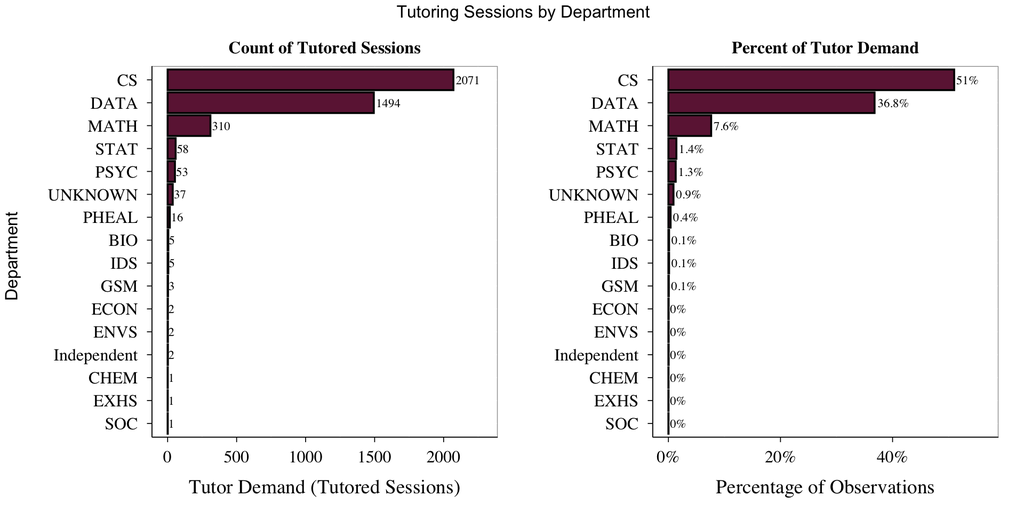

## 1.4 Course Analysis

### 1.4.1 Tutor Demand by Course Summary

Tutored Demand by Class

| Class | Count | Percent of Demand |
| --- | --- | --- |
| CS-151 | 1761 | 43.4% |
| DATA-151 | 1059 | 26.1% |
| CS-152 | 236 | 5.8% |
| MATH-138 | 146 | 3.6% |
| DATA-152 | 138 | 3.4% |
| MATH-251W | 75 | 1.8% |
| DATA-351 | 60 | 1.5% |
| DATA-501 | 60 | 1.5% |
| MATH-280 | 52 | 1.3% |
| DATA-252 | 46 | 1.1% |
| UNKNOWN | 37 | 0.9% |
| DATA-503 | 36 | 0.9% |
| DATA-275 | 25 | 0.6% |
| CS-501 | 24 | 0.6% |
| DATA-299 | 24 | 0.6% |
| PSYC-252 | 23 | 0.6% |
| DATA-502 | 20 | 0.5% |
| PSYC-253 | 18 | 0.4% |
| CS-271 | 17 | 0.4% |
| DATA-399 | 16 | 0.4% |
| STAT-365 | 16 | 0.4% |
| STAT-341 | 14 | 0.3% |
| MATH-150 | 13 | 0.3% |
| STAT-342 | 13 | 0.3% |
| CS-276 | 10 | 0.2% |
| CS-351 | 10 | 0.2% |
| MATH-352 | 9 | 0.2% |
| PHEAL-214 | 9 | 0.2% |

### 1.4.2 Tutor Demand by Course Visualized

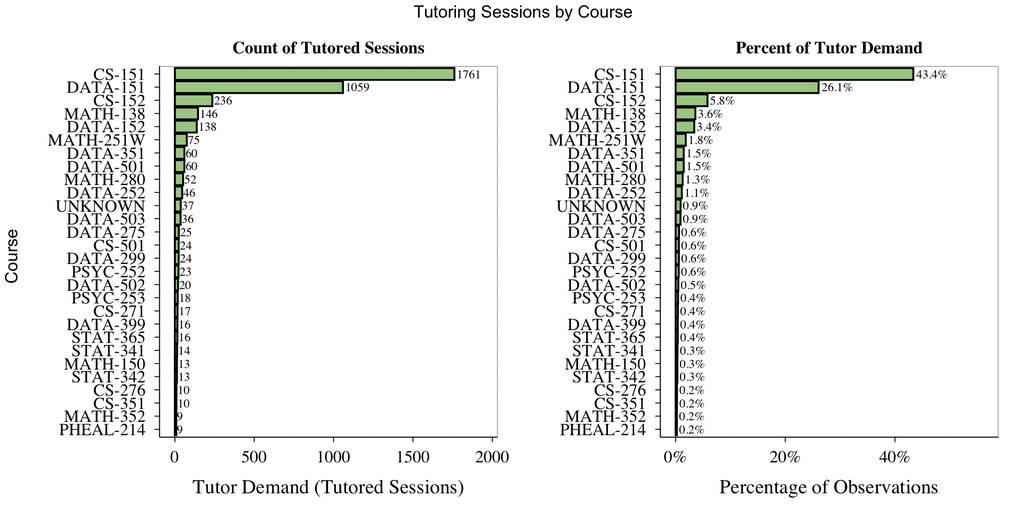

#### Notes:

- The introductory classes within the CS, DATA and MATH departments account for over half of the tutoring sessions. Each of these classes have at least one section every semester, and typically have an above-average enrollment, leading to a high volume of tutoring center visits for those classes.
- The UNKNOWN category groups missing data as well as people who came in for independent projects that were not related to a particular class.

## 1.5 Programming Language Analysis

### 1.5.1 Tutored Demand by Language Summary

Tutored Demand by Language

| Programming Language | Count | Percent of Demand |
| --- | --- | --- |
| Python | 2021 | 49.8% |
| R | 1509 | 37.2% |
| Unknown | 410 | 10.1% |
| SQL | 96 | 2.4% |
| Python/R | 25 | 0.6% |

### 1.5.2 Tutored Demand by Language Visualized

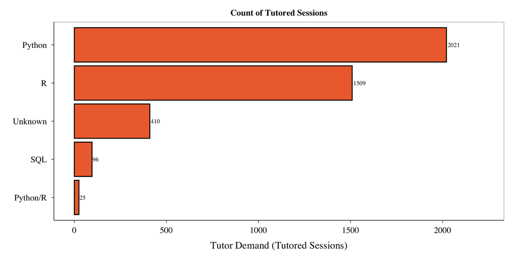

#### Notes:

# 2. Tutored Sessions Over Time

## 2.1 Tutored Sessions Over Time by Class Type

[interactive chart not shown]

#### Notes:

- Please Note: Data is filtered for class types which have over 10 observations, and only months with data are included. This causes a jump from April to August, as the QUAD Center was not open May-July.
- There is a huge spike of DATA related visits in October 2024, which is attributed to an extra credit assignment in an intro DATA class which was mentioned previously.
- Computer Science is consistently the highest tutored class type. This is because CS-151 is the most commonly tutored class and can be supported by a majority of tutors, as well as by section leaders, who work in the QUAD Center as CS-151 specialists and teach out-of-class sessions regarding class concepts.
- STAT visits began in August 2025. This is because it was the opening of the Statistics major and minor, so classes of the STAT type were first officially offered in Fall of 2025.
- PSYC visits tapered off at the end of Spring 2024 and did not return. This is because the QUAD Center no longer had a tutor who could support psychology students. These sessions were typically based around research methods and theory, or the use of ANOVA.
- The less popular class types like GSM (Graduate School of Management), EXHS (Exercise & Health Science), ENVS (Environmental Science), SOC (Sociology), PHEAL (Public Health), and others were often seen for tutoring about quantitative methods, excel, or other theory based topics. Sometimes, there was a coding language being used in these classes, like R, or in the case of ENVS, ArcGIS, which some tutors can support with.

### 2.1.1 A Closer Look at CS

[interactive chart not shown]

#### Notes:

- Please Note: This data includes only the top 6 CS classes, and only months with data are included. This causes a jump from April to August, as the QUAD Center was not open May-July. Any other missing months were a result of no tutoring sessions being conducted for CS in that month.
- CS-151 is the most commonly tutored CS class. As mentioned before, CS-151 is supported by many tutors and section leaders. Additionally, it is a notoriously challenging class, leading to many tutoring sessions.
- The uptick in CS-152 sessions coincides with an addition of an embedded tutor (or TA) in those classes starting in the Spring 2025 semester. In that semester specifically, there were a handful of students who visited the TA in QUAD Center a few times a week.
- In the most recent semesters, there has been a decrease in CS-151 sections, which is why it is not quite as frequent as before, though it remains the most commonly tutored class.

### 2.1.2 A Closer Look at DATA

[interactive chart not shown]

#### Notes:

- Please Note: This data includes only the top 6 DATA classes, and only months with data are included. This causes a jump from April to August, as the QUAD Center was not open May-July. Any other missing months were a result of no tutoring sessions being conducted for DATA in that month.
- There are sharp spikes of DATA-151 visits in both Fall 2024 and Fall 2025. These coincide with the aforementioned extra credit assignment, as well as with the month that midterms are typically scheduled. In Fall 2024 and Fall 2025, the QUAD Center hosted events with the DATA-151 TAs to have a study session for the midterm, which could also explain the spikes.
- In the most recent semesters, there has been a decrease in DATA-151 sections as well.

### 2.1.3 A Closer Look at MATH

[interactive chart not shown]

#### Notes:

- Please Note: This data includes only the top 5 MATH classes, and only months with data are included. This causes a jump from April to August, as the QUAD Center was not open May-July. Any other missing months were a result of no tutoring sessions being conducted for MATH in that month.
- There is an increase in MATH-251W visits in the Spring 2025, and an increase in MATH-138 in Fall 2025. These increases are attributed to the increase in tutors who can support theory-based MATH classes and statistics, as MATH-138 is an introductory stats class. This also explains the presence of MATH-150 and -352 visits in more recent semesters.

## 2.2 Tutored Sessions Per Day

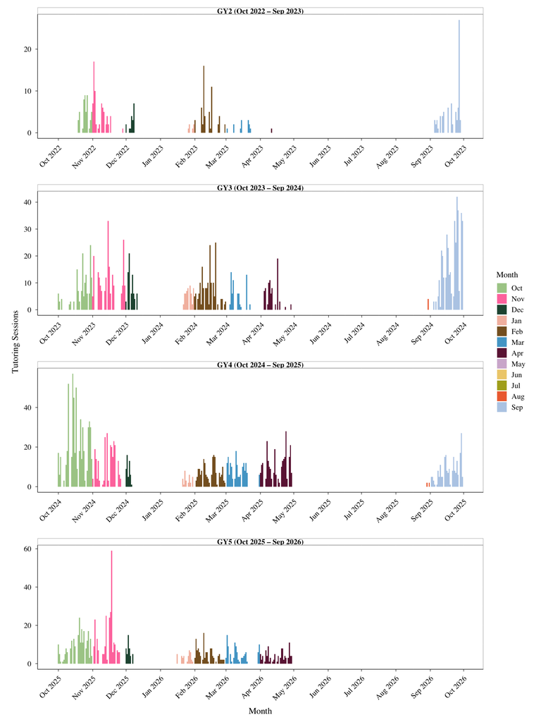

#### Notes:

- Note that the y-axis values increase throughout the years, indicating a general increase in usage.
- Each bar represents one day and the number of visits on that particular day. The Spring semesters often get less usage, which is likely a factor of less introductory classes being offered in Spring semesters.
- September-November being the busiest Fall months makes sense as they are the bulk of the semester and most assignments and midterms take place in that 3 month period. The same pattern is observed in Spring, where February-April are the busiest months.

# 3. Enrollment Analysis

Please note, this is only including the top tutored CS and DATA classes in the QUAD Center. There was no available MATH enrollment data, so MATH enrollment is not included in the analysis below.

## 3.1 Number of Sections Over Time

Number of Sections Offered of Top Classes

| Fall Semester | Fall Class | Fall Sections | Spring Semester | Spring Class | Spring Sections |
| --- | --- | --- | --- | --- | --- |
| FA22 | CS-151 | 1 | SP23 | CS-151 | 1 |
|  | CS-152 | 1 |  | CS-152 | 1 |
|  | DATA-151 | 2 |  | DATA-151 | 1 |
|  | DATA-351 | 1 |  | DATA-152 | 2 |
| FA23 | CS-151 | 3 | SP24 | CS-151 | 2 |
|  | CS-152 | 1 |  | CS-152 | 2 |
|  | DATA-151 | 3 |  | DATA-151 | 2 |
|  | DATA-351 | 1 |  |  |  |
| FA24 | CS-151 | 3 | SP25 | CS-151 | 2 |
|  | CS-152 | 1 |  | CS-152 | 2 |
|  | DATA-151 | 3 |  | DATA-151 | 2 |
|  | DATA-152 | 1 |  |  |  |
|  | DATA-351 | 1 |  |  |  |
| FA25 | CS-151 | 2 | SP26 | CS-151 | 1 |
|  | CS-152 | 1 |  | CS-152 | 2 |
|  | DATA-151 | 3 |  | DATA-151 | 1 |
|  | DATA-152 | 1 |  | DATA-152 | 1 |
|  | DATA-351 | 1 |  | DATA-351 | 1 |

#### Notes:

- Typically, there are less introductory classes in the Spring semesters, leading to higher enrollment in the Fall and therefore, more tutoring sessions.

## 3.2 A Look at Enrollment Over Time

[interactive chart not shown]

#### Notes:

- Enrollment for 151 classes is higher in the fall, and enrollment in 152 classes is higher in the spring. This is because students typically take both classes over one school year, with 151 being a prerequisite for 152 for both CS and DATA classes. There are often more sections of 151 in the fall, and more sections of 152 in the spring.
- The up and down of enrollment, which is particularly obvious for the 100-level classes, is caused by the number of sections offered, which was explored in the above table.

## 3.3 Enrollment vs. Tutoring Sessions

[interactive chart not shown]